# WDA Final - Assesing AIM Water Quality Monitoring Data and Dams in WA State

Andrew Friedman-Herring, Cat Otero, Jackie Van der Hout

Spring 2022

Setup

Purpose of our Research Project:

We chose this project because water quality is an incredibly important issue, and we wanted to see how physical and biological water quality indicators collected by the BLM correlate with each other. Dams also have a very large impact on streams and rivers in the US, as they increase stream temperatures and provide conditions for algal blooms which can reduce water quality. Dams are also a very overlooked piece of infrastructure. By collecting the number of dams upstream of each monitoring site, we are able to add that value to the AIM data set and incorporate it with our analysis of how water quality variables correlate.

Data Used: For our analysis, we used the BLM Assessment, Inventory, and Monitoring (AIM) Data, which we found and data scraped from online in a GeoJSON format.

We also used the Washington State Department of Ecology Inventory of Statewide Dams, which was also found and data scraped from online in a GeoJSON format. This information included latitudes and longitudes for all 57,000 dams in Washington State, as well as their fish barrier classification, which ranged from “Not a barrier” to “Complete Fish Barrier”.

Finally, we used the National Hydrography Dataset of Flowlines and Catchments developed by the US EPA and USGS to connect first two data set spatially. This dataset was used in the form of the NHDplusTools R package to find the catchment and flowline data upstream of each monitoring site.

Spatial Visualization:

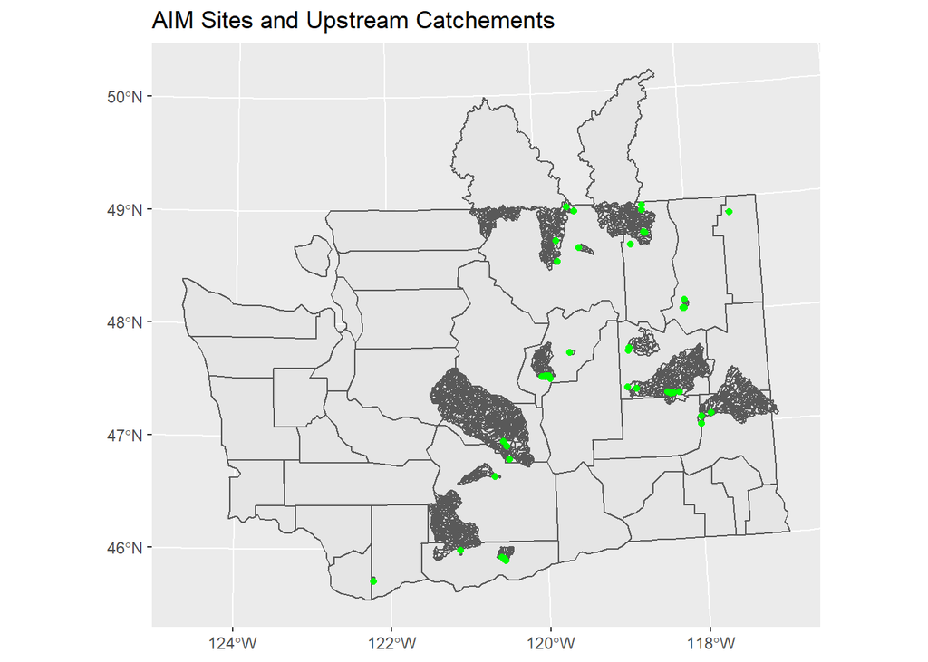

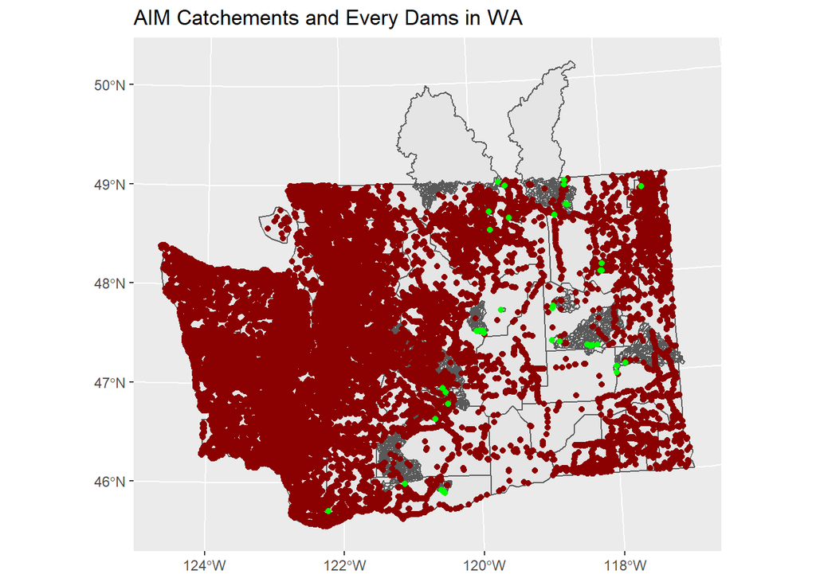

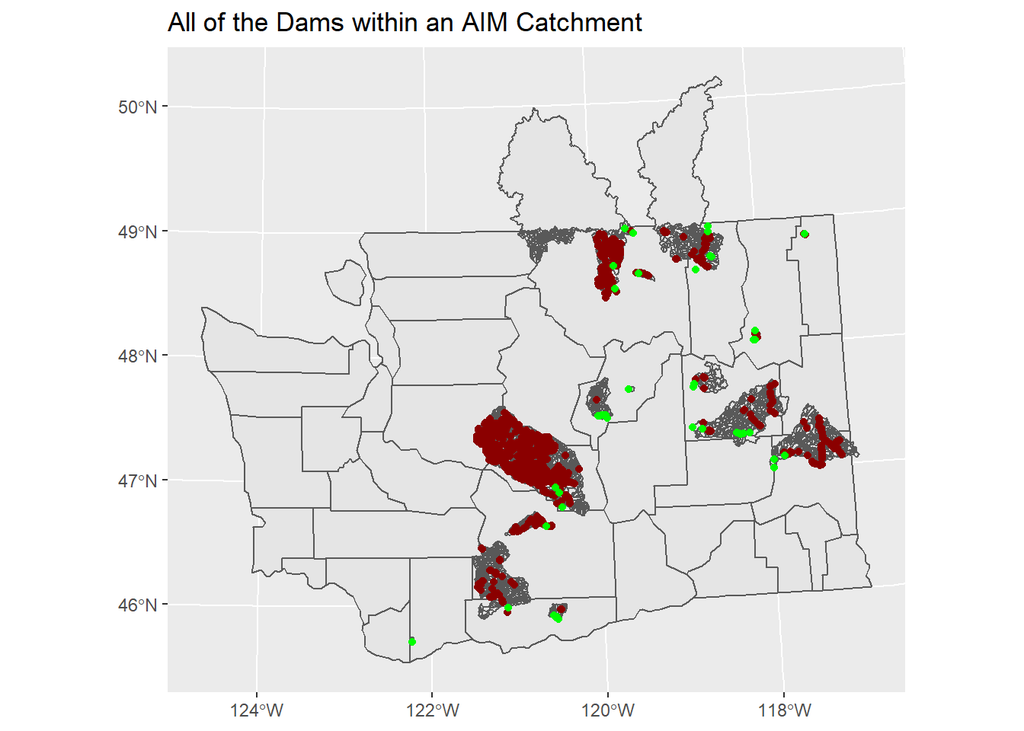

Data Scraping and Wrangling done for WDA

```r
catchment_extract <- function(site_id, waaim_data){
  selectingsites <- filter(waaim_data, SITE_CD == site_id) #takes site ID and filters dataset
  MIDLAT <- selectingsites$MIDLAT
  MIDLONG <- selectingsites$MIDLONG
  start_point <- st_sfc(st_point(c(MIDLONG, MIDLAT)), crs = 4269)
  start_comid <- discover_nhdplus_id(start_point)
  NLDI <- navigate_nldi(list(featureSource = "comid", featureID = start_comid),
                          mode = "upstreamTributaries",
                          distance_km = 1000)
  subset_file <- tempfile(fileext = ".gpkg")
  subset <- subset_nhdplus(comids = as.integer(NLDI$UT$nhdplus_comid),
                         output_file = subset_file, #the above temporary file
                         nhdplus_data = "download",
                         flowline_only = FALSE,
                         return_data = TRUE, overwrite = TRUE)
  catchment <- subset$CatchmentSP
  return(catchment)
}

Dam_catchment_intersect <- function(CATCHMENT, DAM_DATA){
  DAM_DATA_UTM <- st_transform(DAM_DATA, crs = 26910)
  CATCHMENT_UTM <- st_transform(CATCHMENT, crs = 26910)
  DAM_SUBSET <- DAM_DATA_UTM[lengths(
  st_intersects(DAM_DATA_UTM, CATCHMENT_UTM)) > 0,]
  return(DAM_SUBSET)
}

Dam_WAAIM_Join_function <- function(WAAIM_ROW_NUM, WAAIM_DATA, DAM_DATA){
  site_id <- WAAIM_DATA$SITE_CD[WAAIM_ROW_NUM]
  site_catchment <- catchment_extract(site_id, WAAIM_DATA)
  site_dams <- Dam_catchment_intersect(site_catchment, DAM_DATA)
  dams_number <- dim(site_dams)[1]
  return(dams_number)
}

result <- data.frame(matrix(nrow = 45, ncol = 4))
for(i in 1:dim(WAAIM_tidy_utm)[1] ){
result[i,1] <- WAAIM_tidy_utm$SITE_CD[i]
site_catchment <- catchment_extract(result[i,1],WAAIM_tidy_utm)
site_dams <- Dam_catchment_intersect(site_catchment, dam_complete_raw_utm)
result[i,2] <- dim(site_dams)[1]
result[i,3] <- sum(site_catchment$areasqkm)
result[i,4] <- ((result[i,2])/(result[i,3]))
}
result <- result %>%
  rename("Site_CD" = X1,
         "Number_of_dams_upstream" = X2,
         "Catchment_area_sqkm" = X3,
         "Dams_per_sqkm" = X4)

write.csv(result, "./New Data/Dam_catchment_data.csv")
```

# AIC Models and Regressions

We used AIC models to select which explanatory variables to use in a linear model. It can be tempting to throw all variables with available data into a model, but that can get confusing and not actually increase the explanatory power of a model. By using AIC to select variables, we can minimize covariates and end up with a simpler model that is informative and easier to interpret.

We performed regressions to see if and to what extent explanatory variables influence our dependent variables. We used the common p-value of below 0.05 to indicate significant relationships.

Total Phospohrus AIC Results

| Variables_Correlated | Direction_of_Correlation | P-Value |
| --- | --- | --- |
| StreamOrder | Positive | <0.001 |
| BNK_STBLTY | Negative | <0.001 |
| D50 | Negative | <0.001 |
| ReachLength | Positive | <0.01 |
| INSTNT_TEMP | Negative | <0.01 |
| LWD_FREQ | Negative | <0.01 |
| MACROINVRTBRTE_CNT | Negative | <0.01 |
| WDRatio | Negative | <0.05 |

Total Nitrogen AIC Results

| Variables_Correlated | Direction_of_Correlation | P-Value |
| --- | --- | --- |
| OBSRVD_INVRT_RCHNSS | Negative | <0.01 |
| WDRatio | Negative | <0.01 |
| RPRN_VEG_CNPY_CVR | Negative | <0.05 |
| RPRN_VEG_GC | Positive | <0.05 |
| NON_NTVE_HRB | Negative | <0.05 |
| LWD_FREQ | Negative | <0.05 |
| INCSN_HT | Negative | <0.05 |
| CHN_INCSN | Positive | <0.05 |
| WTTD_WT | Positive | <0.05 |
| Dams_per_sqkm | Positive | <0.05 |

Invertibrate Counts AIC Results

| Variables_Correlated | Direction_of_Correlation | P-Value |
| --- | --- | --- |
| NON_NTVE_HRB | Negative | <0.001 |
| TotalN | Negative | <0.001 |
| LWD_FREQ | Negative | <0.01 |
| BNK_STBLTY | Negative | <0.01 |
| INCSN_HT | Negative | <0.01 |
| CHN_INCSN | Positive | <0.01 |
| WTTD_WT | Positive | <0.01 |
| WDRatio | Negative | <0.01 |
| Catchment_area_sqkm | Negative | <0.01 |
| StreamOrder | Positive | <0.05 |
| RPRN_VEG_CNPY_CVR | Negative | <0.05 |
| RPRN_VEG_UNDRSTRY_CVR | Negative | <0.05 |
| RPRN_VEG_GC | Positive | <0.05 |
| NTVE_HRB | Negative | <0.05 |
| Number_of_dams_upstream | Negative | <0.05 |
| D50 | Negative | <0.05 |
| Dams_per_sqkm | Positive | <0.05 |

Bankfull Height AIC Results

| Variables_Correlated | Direction_of_Correlation | P-Value |
| --- | --- | --- |
| NON_NTVE_HRB | Negative | <0.01 |
| LWD_FREQ | Negative | <0.01 |
| OBSRVD_INVRT_RCHNSS | Negative | <0.01 |
| RPRN_VEG_CNPY_CVR | Negative | <0.05 |
| RPRN_VEG_GC | Positive | <0.05 |
| NTVE_HRB | Negative | <0.05 |
| SDGE_RSH | Positive | <0.05 |
| BNK_STBLTY | Negative | <0.05 |
| TotalN | Negative | <0.05 |
| INCSN_HT | Negative | <0.05 |
| CHN_INCSN | Positive | <0.05 |
| WTTD_WT(+) | Positive | <0.05 |
| Number_of_dams_upstream | Negative | <0.05 |
| D50 | Negative | <0.05 |
| Dams_per_sqkm | Positive | <0.05 |

D50 Particle Size AIC Results

| Variables_Correlated | Direction_of_Correlation | P-Value |
| --- | --- | --- |
| WTTD_WT | Positive | <0.001 |
| WDRatio | Negative | <0.001 |
| VEG_CMPLXTY | Negative | <0.01 |
| RPRN_VEG_GC | Positive | <0.01 |
| SDGE_RSH | Positive | <0.01 |
| LWD_FREQ | Negative | <0.01 |
| Number_of_dams_upstream | Negative | <0.01 |
| TotalN | Negative | <0.01 |
| StreamOrder | Positive | <0.05 |
| RPRN_VEG_CNPY_CVR | Negative | <0.05 |
| NON_NTVE_HRB | Negative | <0.05 |
| pH | Positive | <0.05 |
| INCSN_HT | Negative | <0.05 |
| OBSRVD_INVRT_RCHNSS | Negative | <0.05 |
| Dams_per_sqkm | Positive | <0.05 |

Dams/sqkm AIC Results

| Variables_Correlated | Direction_of_Correlation | P-Value |
| --- | --- | --- |
| RPRN_VEG_GC | Negative | <0.01 |
| LWD_FREQ | Positive | <0.01 |
| WTTD_WT | Negative | <0.01 |
| Number_of_dams_upstream.x | Positive | <0.01 |
| WDRatio | Positive | <0.01 |
| VEG_CMPLXTY | Positive | <0.05 |
| RPRN_VEG_CNPY_CVR | Positive | <0.05 |
| NON_NTVE_HRB | Positive | <0.05 |
| SDGE_RSH | Negative | <0.05 |
| pH | Negative | <0.05 |
| LWDVolume | Negative | <0.05 |
| INCSN_HT | Positive | <0.05 |
| OBSRVD_INVRT_RCHNSS | Positive | <0.05 |
| TotalN | Positive | <0.05 |
| D50 | Positive | <0.05 |